# ESM 206 Lab 3

Allison Horst

October 11, 2018

### First: Load packages and data

If knitting to PDF, DEFINITELY set message = FALSE in the chunk where you load the tidyverse, because there is a character in the message that LaTex doesn’t understand and you’ll get an error. Alternatively, use suppressMessages(library(tidyverse))

## A. Probabilities and confidence intervals for the normal distribution

If we have satisfied assumptions to use the Z-distribution, we can use built-in functions in R to calculate probabilities associated with it. The ones we’ll use today are *pnorm* and *qnorm*.

*pnorm* is used to find probabilities (areas under the curve)…the default is finding the area to the LEFT of the value you’re interested in (lower tail)

*qnorm* is used to find the value of the random variable associated with a given percentile (probability)

Let’s say we’re told the following: You are told that the population distribution of cat weights (pounds) is normally distributed with a mean of 9.2 pounds and a standard deviation of 1.4 pounds.

We ask:

1. Why would it be appropriate to use the Z-distribution to calculate probabilities?
2. What is the probability of randomly selecting a cat from the population that:
- weighs less than 8 pounds?
- weighs more than 10 pounds?
- weighs between 8 and 11 pounds?

When in doubt, always draw a picture!

Heads up here: if knitting to a PDF, text in code doesn’t automatically wrap (and there’s actually not a really easy way to do it).

```r
############
# Probabilities with the Z-distribution
############
cat_mean <- 9.2
cat_sd <- 1.4

less_8 <- pnorm(8,
                mean = cat_mean,
                sd = cat_sd) #0.196

more_10 <- pnorm(10,
                 mean = cat_mean,
                 sd = cat_sd,
                 lower.tail = FALSE) #0.28

between_9_10 <- pnorm(11, mean = cat_mean, sd = cat_sd) -
  pnorm(8, mean = cat_mean, sd = cat_sd) #0.705
```

3. At what weight would a cat be at the 90th percentile in weight for the population? At the 30th percentile?

```r
perc_90 <- qnorm(0.9,
                 mean = cat_mean,
                 sd = cat_sd) #10.99 pounds

perc_30 <- qnorm(0.3,
                 mean = cat_mean,
                 sd = cat_sd) #8.47 pounds
```

# B. The t-distribution for confidence intervals and hypothesis test intro (one-sample t-test)

When we use pnorm/dnorm we’re evaluating probabilities using the Z-distribution. What if we don’t know the population sd? If our sample is normally distributed (even at n < 30), or if we have a larger sample (n > 30, due to CLT), we can still use the t-distribution to evaluate probabilities.

We’ll do that in the context of a one-sample hypothesis test to test a claim as an example, using the *t.test()* function.

# Moving on: using the t-distribution

## First, explore the ‘iris’ dataset.

### THIS IS RELEVANT TO YOUR ASSIGNMENT:

To create side-by-side exploratory graphs, you can use facet_wrap to split up graph information by levels of a variable (column).

For example, let’s make exploratory histograms and qq-plots of iris petal lengths, then separate by species.

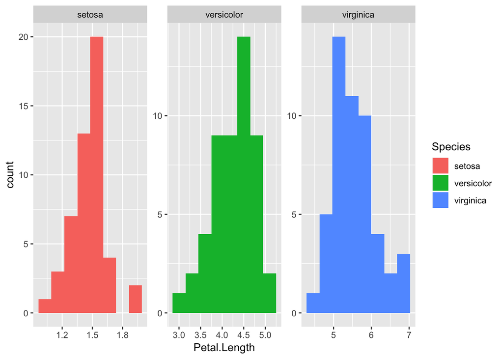

```r
ggplot(iris, aes(x = Petal.Length)) +
  geom_histogram(aes(fill = Species), bins = 8) +
  facet_wrap(~Species, scale = "free")
```

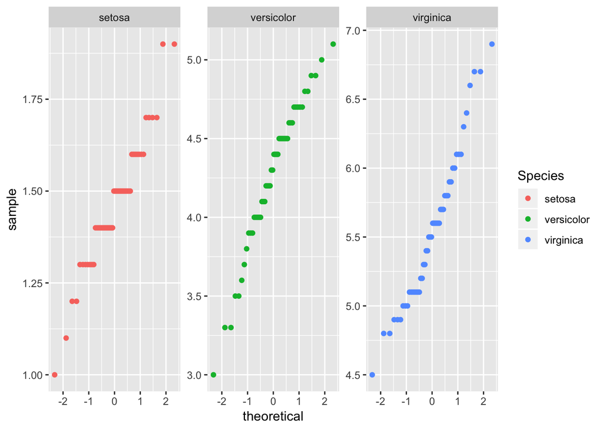

```r
# similarly for qqplot:

ggplot(iris, aes(sample = Petal.Length)) +
  geom_qq(aes(color = Species)) +
  facet_wrap(~Species, scale = "free")
```

Example (using the ‘iris’ dataset): We read a claim that the mean petal length of setosa irises is 1.5cm. We question that claim, and luckily have Edgar Anderson’s iris data to use as a sample. Based on Anderson’s measurements, do we have enough evidence to reject the claim?

1. First, create a subset that only contains information for setosa petal lengths:

```r
setosa_petals <- iris %>%
  filter(Species == "setosa") %>%
  select(Petal.Length) %>%
  rename(length = Petal.Length)
```

2. Next, do some exploring! This is always necessary.

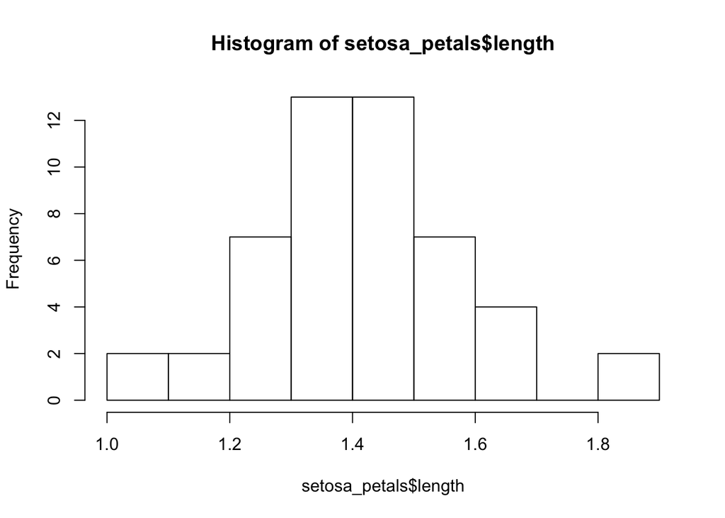

```r
# Look at it
hist(setosa_petals$length)
```

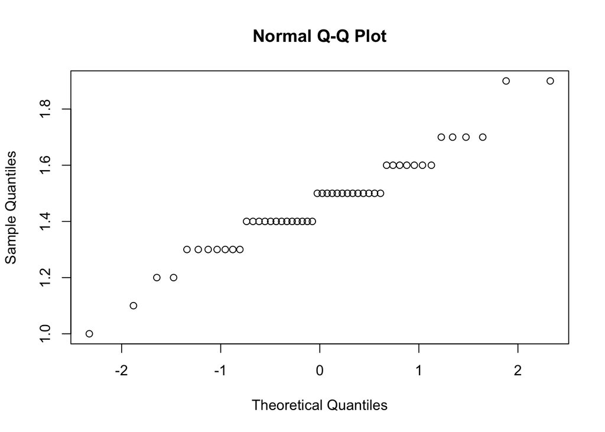

```r
qqnorm(setosa_petals$length)
```

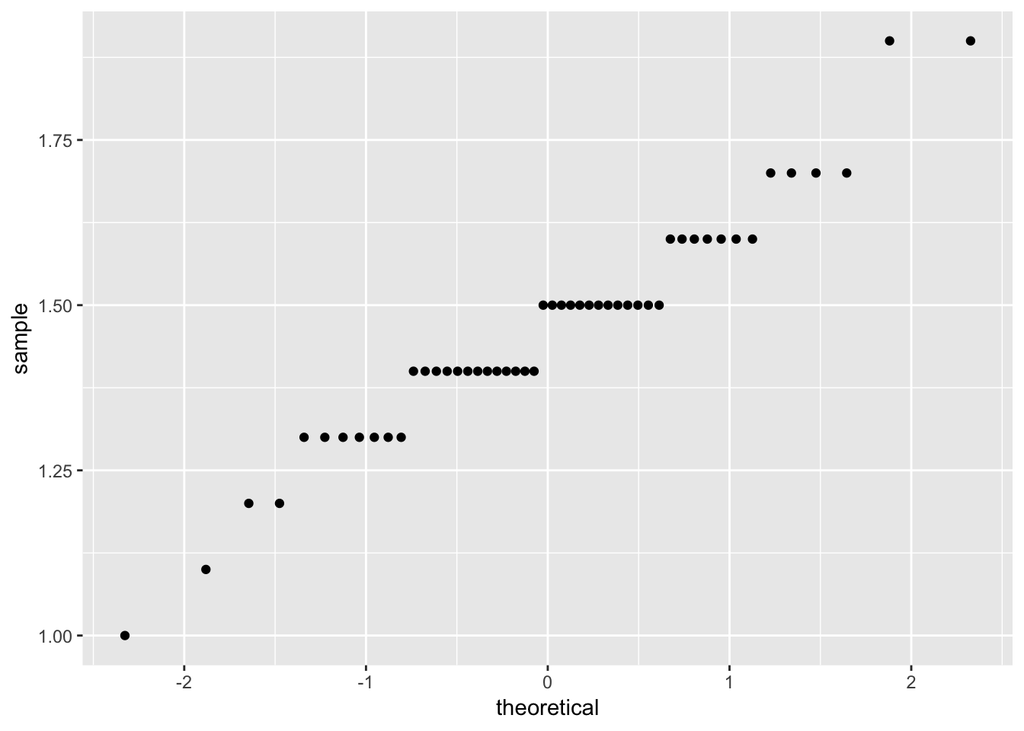

```r
# In ggplot:

ggplot(setosa_petals, aes(sample = length)) +
  geom_qq()
```

```r
mean_pl <- mean(setosa_petals$length) # 1.462
sd_pl <- sd(setosa_petals$length) #0.173
```

3. Find the 95% confidence interval for setosa iris petal length. What does that mean?

Also uses t.test(default for one sample is a 95% confidence level)

```r
setosa_ci <- t.test(setosa_petals$length)
setosa_ci
```

```
##
##  One Sample t-test
##
## data:  setosa_petals$length
## t = 59.528, df = 49, p-value < 2.2e-16
## alternative hypothesis: true mean is not equal to 0
## 95 percent confidence interval:
##  1.412645 1.511355
## sample estimates:
## mean of x
##     1.462
```

```r
# 95 percent confidence interval:
#  1.412645 1.511355

# "Mean setosa petal length (n = 50) is 1.46 cm, with a 95% confidence interval of [1.41, 1.51] cm."

# What if we wanted to find an 80% confidence interval?

setosa_ci_80 <- t.test(setosa_petals$length, conf.level = 0.8)
setosa_ci_80
```

```
##
##  One Sample t-test
##
## data:  setosa_petals$length
## t = 59.528, df = 49, p-value < 2.2e-16
## alternative hypothesis: true mean is not equal to 0
## 80 percent confidence interval:
##  1.430095 1.493905
## sample estimates:
## mean of x
##     1.462
```

4. Now, we’ll test the claim using a two-sided, one-sample t-test.

Null hypothesis: Mean petal length for setosa irises is 1.5cm. Alternative hypothesis: Mean petal length is NOT 1.5cm (two-sided).

```r
tpetal <- t.test(setosa_petals$length, mu = 1.5)
# p = 0.12. What does this mean? Do we have enough evidence to reject the null?
```

There is insufficient evidence to reject the claim that mean setosa iris petal length is 1.5 cm (t(49) = -1.55, p = 0.13).

5. What if we read a claim that the mean petal length is 1.6 cm, but we think that the true mean is LOWER than 1.6 cm?

```r
tpetal_lower <- t.test(setosa_petals$length, mu = 1.6, alternative = "less")
# p = 4.5e-07
```

If the true mean is 1.6cm, there is only a probability of 4.5x10^-7 that a sample (n = 50) drawn from that population would have a mean of OUR sample mean (1.462cm) or less by random chance…it’s more likely that the claim is wrong, and that the true mean is actually lower.

Based on our sample (mean = 1.46, n = 50), we conclude that the mean petal length for setosa irises is lower than the claim of 1.6 cm (t(49) = -5.6, p < 0.001).

# C. Two-sample t-tests (Flint water)

Briefly describe dataset (Flint lead in water). Instructions for water testing (flush for 3 - 4 minutes before sampling) were intentionally producing false low estimates of lead in the water. But how much of a difference was that making? Today we’ll explore some Flint water sampling data to see.

First, open the Excel file ‘flint_pb’ in Excel and explore. Notice that it’s not very nicely formatted. Let’s make a copy FIRST (don’t mess with raw data - always make a copy). Then simplify the column names, and save the active sheet (with data) as a .csv. Once you’ve saved it, drop into your project folder (if you didn’t automatically save it there anyway).

I’ll rename mine: “sample_id”, “zip”,“ward”,“pb_1”,“pb_2”,“pb_3”.

Save the simplified file (csv), then drop it into your project folder. Now it’s in your working directory…let’s load our packages and data

1. Exploration and wrangling

```r
pb <- flint %>%
  select(pb_1, pb_3)

summary(pb)
```

```
##       pb_1              pb_3
##  Min.   :  0.344   Min.   : 0.031
##  1st Qu.:  1.578   1st Qu.: 0.306
##  Median :  3.521   Median : 0.831
##  Mean   : 10.646   Mean   : 3.661
##  3rd Qu.:  9.050   3rd Qu.: 2.740
##  Max.   :158.000   Max.   :94.520
```

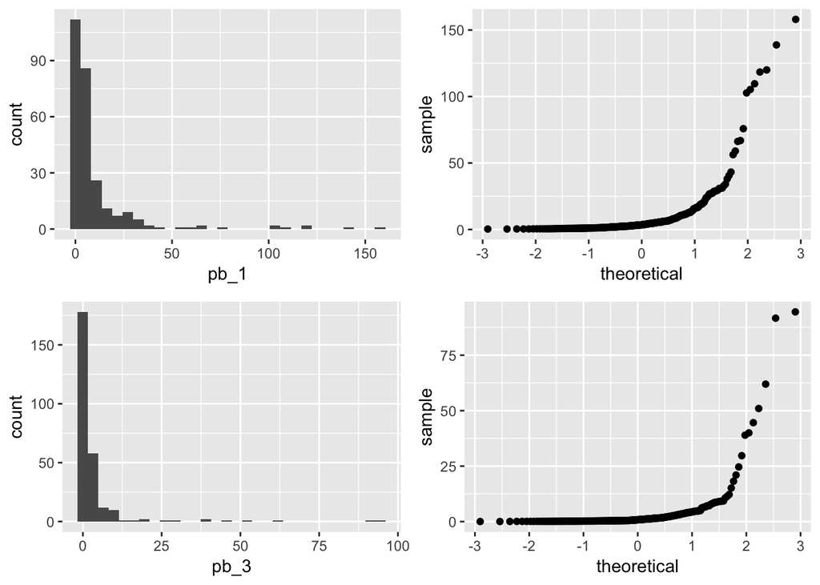

```r
pb1hist <- ggplot(pb, aes(x = pb_1)) +
  geom_histogram()

pb1qq <- ggplot(pb, aes(sample = pb_1)) +
  geom_qq()

pb3hist <- ggplot(pb, aes(x = pb_3)) +
  geom_histogram()

pb3qq <- ggplot(pb, aes(sample = pb_3)) +
  geom_qq()

ggarrange(pb1hist, pb1qq, pb3hist, pb3qq) # Only do this if they're going to get ggpubr
```

# These are really non-normally distributed…why would we still be able to use the t-distribution to compare *means* (assuming that we think *means* is an interesting thing to compare…)

2. T-test

```r
flint_t <- t.test(pb$pb_1, pb$pb_3, alternative = "greater", paired = TRUE)
flint_t
```

```
##
##  Paired t-test
##
## data:  pb$pb_1 and pb$pb_3
## t = 6.3748, df = 270, p-value = 3.946e-10
## alternative hypothesis: true difference in means is greater than 0
## 95 percent confidence interval:
##  5.176714      Inf
## sample estimates:
## mean of the differences
##                6.985288
```

Are lead concentrations significantly reduced post-flushing? YES…by a LOT. Post-flushing Pb concentrations are significantly lower than pre-flushing concentrations.